[figure not shown]

# Análise da base de dados Exercicio_Python_CRM .xlsx

##### Primeira parte da análise:

- análise descritiva da base de Transações
- agregação Ano e Mês
- KPI Ticket Médio

###### nesta primeira parte da análise é possível verificar que:

- a base apenas possui dados para 01-2022 até 09-2022 e depois 01-2023 até 09-2023 faltando o último trimestre dos dois anos; época de Natal, black friday e dia das crianças!
- as vendas de 2023 apenas se recuperaram no terceiro trimestre. É provável que esta recuperação continuasse no terceiro semestre indicando uma tendência de crescimento ao longo do ano, o que não acontece em 2022.
- 2022 teve um pico em Março (semana do consumidor), mas houve um decréscimo em junho (dia dos namorados). Em 2023 parece que houve uma venda melhor relacionada ao calendário de junho.
- o ano de 2023 teve menos promoções e menos Unidades vendidas em relação a 2022, porém obteve um Valor Total maior indicando que houve um Ticket Médio maior em 2023 em relação a 2022
- o Ticket Médio de 2023 foi sempre maior que 2022 no agregado mês a mês

[interactive chart not shown]

###### - As unidades vendidas de 2023 só crescem no terceiro semestre, assim como o valor total. O comportamento é praticamente o inverso de 2022

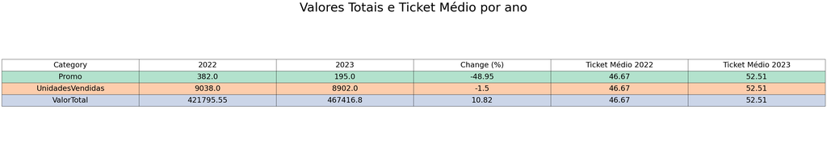

###### - praticamente metade das promoções em 2023 em relação a 2022

###### - queda nas unidades vendidas de 1,5% em 2023 em relação a 2022

###### - Aumento de faturamento - Valor Total de 10,82% em 2023 em relação a 2022

###### - Aumento do Ticket Médio em 2023 em relação a 2022

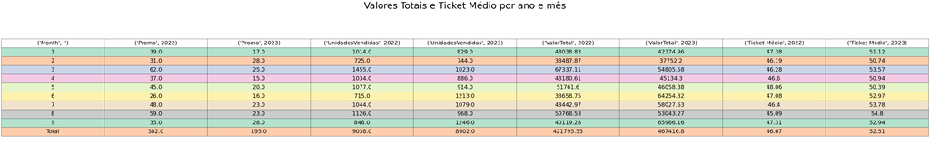

###### - destaque Ticket Médio maior em todos os meses de 2023

[interactive chart not shown]

###### - movimentos atípicos de volume de vendas em 2022 em Março e em 2023 em junho e setembro

###### - Ticket Médio é outro destaque em 2023

#### Segunda parte da análise:

- explorando os dados de transações com as Marcas e suas categorias

##### nesta segunda parte da análise é possível verificar que:

###### O top vermelho gammaz - teve ótimo desempenho,

###### - ficou em segundo lugar no rank de Ticket Médio (TM) no ano de 2023. Caiu 1 posição em relação a 2022

###### - se manteve em primeiro em relação a Unidades Vendidas e Valor Total (VT) 2022 e 2023

###### - fez menos promoções em 2023 em relação a 2022 - caiu de sexto em quantidade de promoções para sétimo

###### mas o Botton azul Gammaz também teve destaque!

###### 2023 Bottom Azul Marca GammaZ -> TM - 88.517723 VT - 75759.52

###### 2023 Top Vermelho Marca GammaZ -> TM - 83.774699 VT - 146329.22

###### O Botton azul gammaz que não foi vendido em 2022 teve um desempenho melhor em 2023 quando se olha pra Ticket Médio.

###### A Marca Gammaz no geral teve um bom desempenho pra Ticket Médio e Valor Total, ultrapassando em Valor Total a Marca AlfaX

###### As promoções não impulsionaram o negócio de forma geral

###### Cores vermelhas são representativas em vendas, mas um destaque foram peças azuis, que melhoraram tanto em quantidade vendida, quanto em aumento de ticket médio e valor Total

###### Houve crescimento de Ticket médio de peças tipo Botton e também Valor Total, o que ajuda a explicar o sucesso do Botton azul gammaz

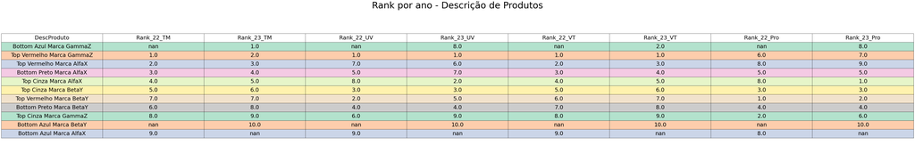

###### - top 3 são destaques em Ticket Médio e Faturamento

[interactive chart not shown]

###### - GammaZ ultrapassa AlfaX em faturamento em 2023

[interactive chart not shown]

###### - GammaZ ultrapassa AlfaX em vendas em 2023

[interactive chart not shown]

###### - vermelho é sempre destaque

###### - Azul tem desempenho muito forte em 2023, se recuperando em faturamento, mas principalemnte em Ticket Médio

[interactive chart not shown]

###### - vermelho é sempre destaque em vendas

###### - Azul tem promoções em 2023

[interactive chart not shown]

###### - Top fatura mais, mas Bottom melhora Ticket médio em 2023

[interactive chart not shown]

###### - Ticket Médio e faturamento - destaques Top Vermelho e Bottom Azul GammaZ

[interactive chart not shown]

##### Terceira parte da análise:

- Clientes e Lojas

###### nesta terceira parte da análise é possível verificar que:

Ticket Médio por ID_Loja e Ano - a barra em vermelho indica a Loja 5 com melhor Ticket Médio agregado no ano 2023 (agregado de todos os produtos)

[interactive chart not shown]

- Loja e Marca - Rank por Ticket médio 2023

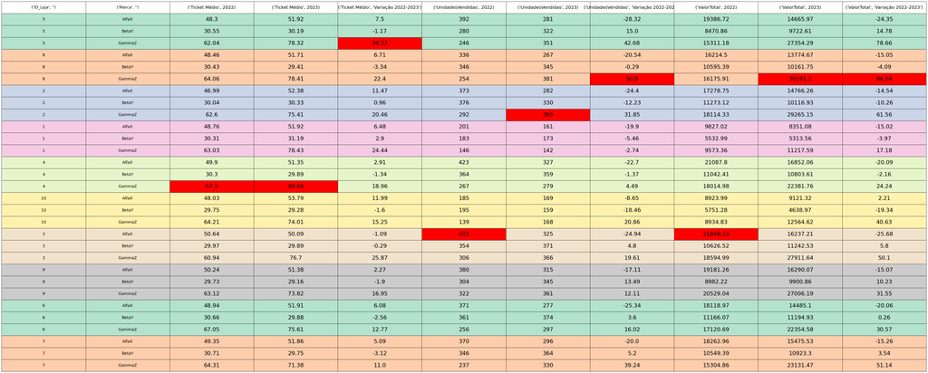

- Loja e UF - Rank por Ticket médio 2023

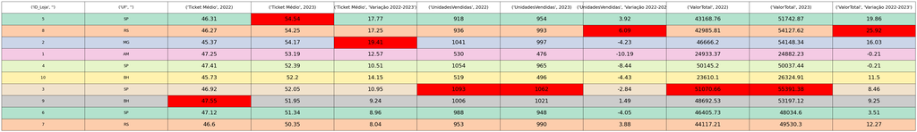

- Loja e Classe Social - Rank por Ticket médio 2023

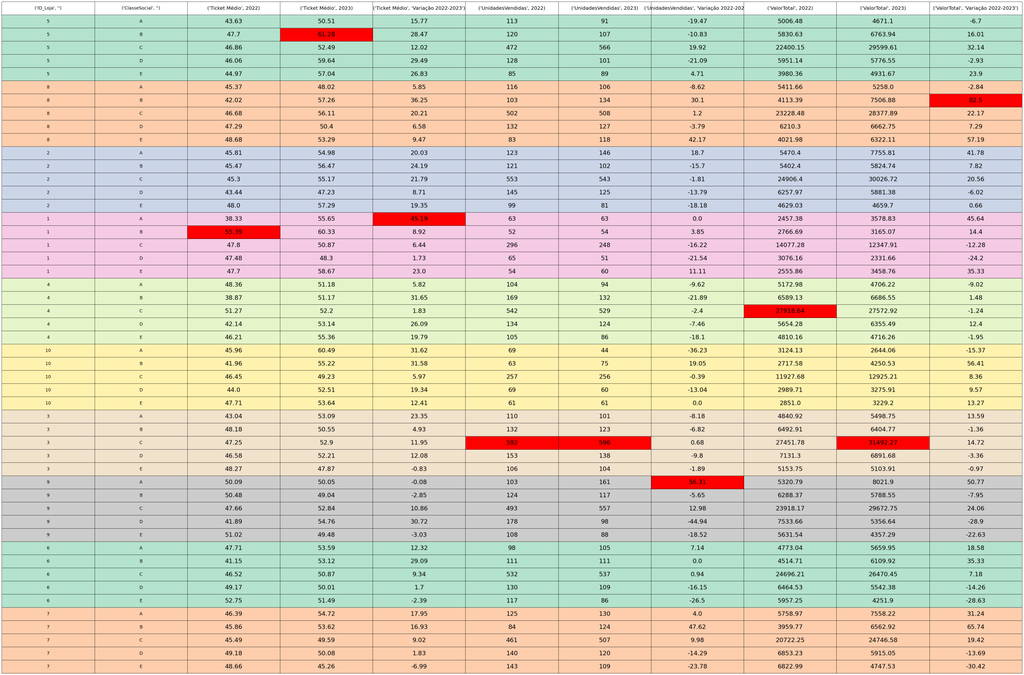

- Loja e Genero - Rank por Ticket médio 2023

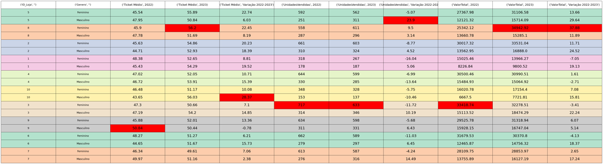

- Loja e Faixa de Idade - Rank por Ticket médio 2023

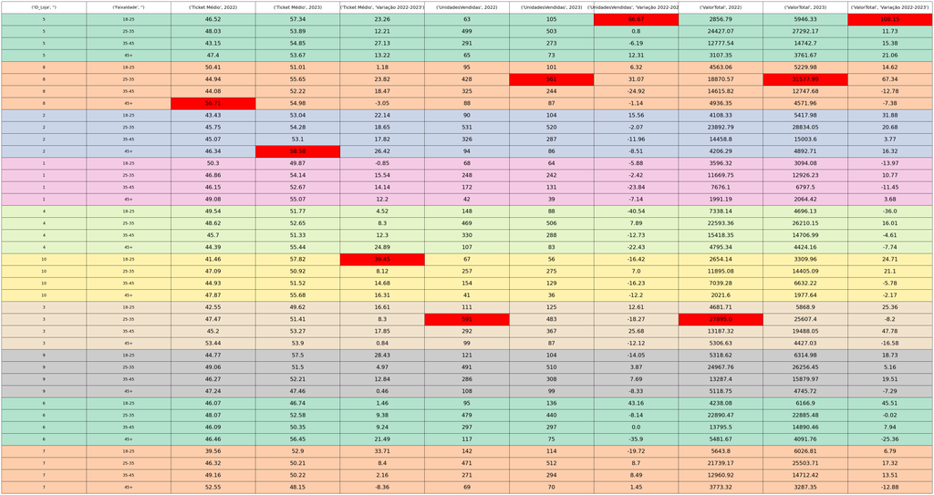

##### Quarta parte da análise:

- Teste

###### nesta quarta parte da análise é possível verificar que:

O valor de p é 0,185 ou 18,5%. Um valor de p menor que 0,05 geralmente é considerado evidência forte o suficiente para rejeitar a hipótese nula e aceitar a hipótese alternativa.

- H0 (Hipótese nula): O teste não rejeita a hipótese nula pois não há associação significativa entre "Grupo" e "Comprou". Em outras palavras, a taxa de compra é praticamente a mesma para os grupos 'CONTROLE' e 'TESTE'.
- H1 (Hipótese alternativa): O Teste rejeita hipótese alternativa que seria uma associação significativa entre "Grupo" e "Comprou".

Portanto não houve diferença significativa entre o Modelo ANTIGO e NOVO de disparo de e-mails.

|  | Grupo | conversion_rate | opening_rate |
| --- | --- | --- | --- |
| 0 | CONTROLE | 58.49% | 86.79% |
| 1 | TESTE | 73.33% | 91.11% |

```
Valor de p: 0.1850463335809991
Não há relação significativa entre Grupo e Comprou
```

### Próximos Passos

- testar a capacidade dos dados em identificar tendências, sazonalidade e predições utlizando o algoritmo PROPHET para a timeseries Data e dados de vendas para melhor interpretar o calendário e seus momentos importantes para o varejo de roupas
- outros dados externos podem auxiliar nos modelos (Bureau de Dados, IBGE, Ministérios,...)
- dados de concorrência

##### sobre a análise

- vale manter as estratégias em relação a peças vermelhas. Estão bem consolidadas nas preferências dos clientes.
- na possibilidade de promoção de outros produtos Azul pode ser uma cor interessante
- as estratégias de MKT precisam ser renovadas.
  - as promoções não teem surtido efeito
  - a NOVA estratégia de email marketing também não se mostrou significativa

```
0
```